# Acoustic correlates of perceived prominence in German and Catalan: Bayesian Modeling

Aleksandra Ćwiek, Alina Gregori, Paula G. Sánchez-Ramón, Frank Kügler, Pilar Prieto

08 Januar, 2025

# 1 Introduction

This is the analysis using Bayesian Modeling.

# 2 Data preparation

## 2.1 Source setup

```r
########## folders ##########
# current folder (first go to session -> set working directory -> to source file location)
parentfolder <- dirname(getwd())

data          <- paste0(parentfolder, '/MultIS_data/')
audiodata     <- paste0(parentfolder, '/audio_processed/')
syllables     <- paste0(audiodata,    'syllables/')
dataworkspace <- paste0(parentfolder, '/data_processed/')
datamerged    <- paste0(parentfolder, '/data_merged/')
datasets      <- paste0(parentfolder, '/datasets/')
models        <- paste0(parentfolder, '/models/')
plots         <- paste0(parentfolder, '/plots/')
scripts       <- paste0(parentfolder, '/scripts/')

########## source file ##########

#source(paste0(scripts, "adjectives-preparation.R"))

#################### packages ####################
# Data Manipulation
library(tibble)
library(stringr)
library(tidyverse) # includes readr, tidyr, dplyr, ggplot2
packageVersion("tidyverse")
```

```
## [1] '2.0.0'
```

```r
library(data.table)

# Plotting
library(ggforce)
library(ggpubr)
library(gridExtra)
library(corrplot)

# Bayesian
library(brms); packageVersion("brms")
```

```
## [1] '2.22.0'
```

```r
library(cmdstanr); packageVersion("cmdstanr")
```

```
## [1] '0.8.1'
```

```r
library(emmeans); packageVersion("emmeans")
```

```
## [1] '1.10.5'
```

```r
library(posterior); packageVersion("posterior")
```

```
## [1] '1.6.0'
```

```r
# tidybayes https://mjskay.github.io/tidybayes/articles/tidy-brms.html
library(magrittr)
library(dplyr)
library(purrr)
library(forcats)
library(tidyr)
library(modelr)
library(ggdist)
library(tidybayes)
library(ggplot2)
library(cowplot)
library(rstan)
library(brms)
library(ggrepel)
library(RColorBrewer)
library(gganimate)
library(posterior)
library(distributional)

theme_set(theme_tidybayes() + panel_border())


# use all available cores for parallel computing
options(mc.cores = parallel::detectCores())

colorBlindBlack8  <- c("#000000", "#E69F00", "#56B4E9", "#009E73",
                       "#F0E442", "#0072B2", "#D55E00", "#CC79A7")
```

## 2.2 Functions

```r
# Function to back-transform fixed effects from a model
backtransform_fixef <- function(model) {

  # Extract fixed effects (population-level)
  fixef_output <- fixef(model)

  # Extract the estimates for the intercept and percProm levels
  intercept <- fixef_output["Intercept", "Estimate"]
  percProm1 <- fixef_output["percProm1", "Estimate"]
  percProm2 <- fixef_output["percProm2", "Estimate"]
  percProm3 <- fixef_output["percProm3", "Estimate"]

  # Combine the effects for each percProm level before applying exp()
  combined_effects <- data.frame(
    percProm_level = c("percProm0", "percProm1", "percProm2", "percProm3"),
    Estimate = exp(c(intercept,  # percProm0 is just the intercept
                     intercept + percProm1,  # Add percProm1 effect to intercept
                     intercept + percProm2,  # Add percProm2 effect to intercept
                     intercept + percProm3)),  # Add percProm3 effect to intercept
    # You can calculate confidence intervals by combining Q2.5 and Q97.5 as well
    Q2.5 = exp(c(fixef_output["Intercept", "Q2.5"],  # percProm0 interval
                 fixef_output["Intercept", "Q2.5"] + fixef_output["percProm1", "Q2.5"],  # percProm1 interval
                 fixef_output["Intercept", "Q2.5"] + fixef_output["percProm2", "Q2.5"],  # percProm2 interval
                 fixef_output["Intercept", "Q2.5"] + fixef_output["percProm3", "Q2.5"])),  # percProm3 interval
    Q97.5 = exp(c(fixef_output["Intercept", "Q97.5"],
                  fixef_output["Intercept", "Q97.5"] + fixef_output["percProm1", "Q97.5"],
                  fixef_output["Intercept", "Q97.5"] + fixef_output["percProm2", "Q97.5"],
                  fixef_output["Intercept", "Q97.5"] + fixef_output["percProm3", "Q97.5"]))
  )

  return(combined_effects)
}

combine_fixed_random_backtransforming <- function(participant_id) {

  # Get the random effects for the given participant
  rand_intercept <- ranef_output$participant[participant_id, , "Intercept"]
  rand_percProm1 <- ranef_output$participant[participant_id, , "percProm1"]
  rand_percProm2 <- ranef_output$participant[participant_id, , "percProm2"]
  rand_percProm3 <- ranef_output$participant[participant_id, , "percProm3"]

  # Combine fixed and random effects
  participant_effects <- data.frame(
    percProm_level = c("percProm0", "percProm1", "percProm2", "percProm3"),
    Estimate = exp(c(
      intercept + rand_intercept["Estimate"],
      intercept + percProm0 + rand_intercept["Estimate"] + rand_percProm1["Estimate"],
      intercept + percProm2 + rand_intercept["Estimate"] + rand_percProm2["Estimate"],
      intercept + percProm3 + rand_intercept["Estimate"] + rand_percProm3["Estimate"]
    )),
    Est.Error = c(
      sqrt(fixef_output["Intercept", "Est.Error"]^2 + rand_intercept["Est.Error"]^2),
      sqrt(
        fixef_output["Intercept", "Est.Error"]^2 + fixef_output["percProm1", "Est.Error"]^2 +
        rand_intercept["Est.Error"]^2 + rand_percProm1["Est.Error"]^2
      ),
      sqrt(
        fixef_output["Intercept", "Est.Error"]^2 + fixef_output["percProm2", "Est.Error"]^2 +
        rand_intercept["Est.Error"]^2 + rand_percProm2["Est.Error"]^2
      ),
      sqrt(
        fixef_output["Intercept", "Est.Error"]^2 + fixef_output["percProm3", "Est.Error"]^2 +
        rand_intercept["Est.Error"]^2 + rand_percProm3["Est.Error"]^2
      )
    ),
    Q2.5 = exp(c(
      intercept + rand_intercept["Q2.5"],
      intercept + percProm0 + rand_intercept["Q2.5"] + rand_percProm1["Q2.5"],
      intercept + percProm2 + rand_intercept["Q2.5"] + rand_percProm2["Q2.5"],
      intercept + percProm3 + rand_intercept["Q2.5"] + rand_percProm3["Q2.5"]
    )),
    Q97.5 = exp(c(
      intercept + rand_intercept["Q97.5"],
      intercept + percProm0 + rand_intercept["Q97.5"] + rand_percProm1["Q97.5"],
      intercept + percProm2 + rand_intercept["Q97.5"] + rand_percProm2["Q97.5"],
      intercept + percProm3 + rand_intercept["Q97.5"] + rand_percProm3["Q97.5"]
    ))
  )

  participant_effects$participant <- participant_id
  return(participant_effects)
}

combine_fixed_random_student <- function(participant_id) {

  # Get the random effects for the given participant
  rand_intercept <- ranef_output$participant[participant_id, , "Intercept"]
  rand_percProm1 <- ranef_output$participant[participant_id, , "percProm1"]
  rand_percProm2 <- ranef_output$participant[participant_id, , "percProm2"]
  rand_percProm3 <- ranef_output$participant[participant_id, , "percProm3"]

  # Combine fixed and random effects for each percProm level
  participant_effects <- data.frame(
    percProm_level = c("percProm0", "percProm1", "percProm2", "percProm3"),

    # Estimate: sum of fixed and random effects
    Estimate = c(
      rand_intercept["Estimate"],
      rand_intercept["Estimate"] + rand_percProm1["Estimate"],
      rand_intercept["Estimate"] + rand_percProm2["Estimate"],
      rand_intercept["Estimate"] + rand_percProm3["Estimate"]
    ),

    # Standard Error: combining errors using sqrt of sum of squares
    Est.Error = c(
      sqrt(rand_intercept["Est.Error"]^2),
      sqrt(rand_intercept["Est.Error"]^2 + rand_percProm1["Est.Error"]^2),
      sqrt(rand_intercept["Est.Error"]^2 + rand_percProm2["Est.Error"]^2),
      sqrt(rand_intercept["Est.Error"]^2 + rand_percProm3["Est.Error"]^2)
    ),

    # Q2.5 and Q97.5: these need to be simulated to reflect the full posterior distribution
    Q2.5 = c(
      rand_intercept["Q2.5"],
      rand_intercept["Q2.5"] + rand_percProm1["Q2.5"],
      rand_intercept["Q2.5"] + rand_percProm2["Q2.5"],
      rand_intercept["Q2.5"] + rand_percProm3["Q2.5"]
    ),
    Q97.5 = c(
      rand_intercept["Q97.5"],
      rand_intercept["Q97.5"] + rand_percProm1["Q97.5"],
      rand_intercept["Q97.5"] + rand_percProm2["Q97.5"],
      rand_intercept["Q97.5"] + rand_percProm3["Q97.5"]
    )
  )

  participant_effects$participant <- participant_id
  return(participant_effects)
}

# Function to compute summary statistics for each difference
compute_summary <- function(diff) {
  estimate <- mean(diff)
  se <- sd(diff)
  ci_lower <- quantile(diff, 0.025)
  ci_upper <- quantile(diff, 0.975)
  prob <- mean(diff > 0)  # Posterior probability that difference > 0
  return(data.frame(Estimate = estimate, SE = se, CI.Lower = ci_lower, CI.Upper = ci_upper, Prob = prob))
}
```

## 2.3 Load in data frames

```r
participant_info <- read_delim(paste0(data,"ParticipantInfo_GERCAT.csv"), delim = ";")

# Load the information about duration of each segment (if needed)
data_df <- read.table(paste0(syllables, "fileDurationsDF.csv"), header = TRUE, sep = ',')

# Load cleaned syllable data
data <- read_csv(paste0(datasets, "data_cleaned.csv"))

# Load cleaned targets data
targets <- read_csv(paste0(datasets, "targets.csv"))

# Load cleaned targets with pre-post data
data_prepost <- read_csv(paste0(datasets, "data_prepost.csv"))
```

## 2.4 You can add participant info

```r
# Process participant_info so that participant number column is only number
participant_info$Participant <- parse_number(participant_info$Participant)

# Convert the column names of participant_info to lowercase
colnames(participant_info) <- tolower(colnames(participant_info))

# Merge the dataframes by "Participant" and "Language"
data_prepost <- merge(data_prepost, participant_info, by = c("participant", "language"), all.x = TRUE)
```

# 3 Data preparation

We split the table in two languages. Then, we only keep the relevant columns (top 10 features).

```r
# Turn variables to factors
data_prepost$percProm <- as.factor(data_prepost$percProm)
data_prepost$itemNum <- as.factor(data_prepost$itemNum)
data_prepost$focus <- as.factor(data_prepost$focus)
data_prepost$participant <- as.factor(data_prepost$participant)

# Add contrast-coded gender info (in case we want to use if)
data_prepost <- data_prepost %>%
  mutate(gender_s = case_when(gender == "female" ~ 0.5,
                              gender == "male" ~ -0.5))

# First, remove some columns for both languages
data_prepost <- data_prepost %>%
  select(-f1_freq_median, -f1_freq_median_norm, -f2_freq_median, -f2_freq_median_norm,
         -f1_freq_medianPre, -f1_freq_median_normPre, -f2_freq_medianPre, -f2_freq_median_normPre,
         -f1_freq_medianPost, -f1_freq_median_normPost, -f2_freq_medianPost, -f2_freq_median_normPost
         )

# Adapt duration scale (because we set the priors for ms, not s)
data_prepost$duration <- data_prepost$duration * 1000
data_prepost$durationPre <- data_prepost$durationPre * 1000
data_prepost$durationPost <- data_prepost$durationPost * 1000
data_prepost$duration_noSilence <- data_prepost$duration_noSilence * 1000
data_prepost$duration_noSilencePre <- data_prepost$duration_noSilencePre * 1000
data_prepost$duration_noSilencePost <- data_prepost$duration_noSilencePost * 1000

# Create data_prepost_german for rows where language is German
data_prepost_ger <- data_prepost %>%
  filter(language == "German")

# Create data_prepost_catalan for rows where language is Catalan
data_prepost_cat <- data_prepost %>%
  filter(language == "Catalan")

# Select columns for German
data_prepost_ger <- data_prepost_ger %>%
  select(fileName, language, participant, gender, gender_s, age,
         itemNum, focus, annotationNum, annotationNumTarget,
         word, syllText, syllTextPre, syllTextPost, percProm,
         f0_slope, f0_slope_norm,
         pitch_median, pitch_median_norm,
         ampl_sd,
         ampl_noSilence_medianPost,
         ampl_noSilence_median,
         duration,
         flux_sd,
         flux_median,
         ampl_noSilence_sd,
         pitch_medianPost, pitch_median_normPost)

# Select columns for Catalan
data_prepost_cat <- data_prepost_cat %>%
  select(fileName, language, participant, gender, gender_s, age,
         itemNum, focus, annotationNum, annotationNumTarget,
         word, syllText, syllTextPre, syllTextPost, percProm,
         duration,
         f0_slopePost, f0_slope_normPost,
         fmDep_medianPost,
         entropySh_sd,
         flux_medianPost,
         ampl_medianPost,
         specCentroid_median,
         duration_noSilence,
         durationPre,
         ampl_sd)
```

Add information on pauses to test separately. First in German.

```r
# First, let's create a copy of data_prepost_ger to work on
data_prepost_ger_updated <- data_prepost_ger

# Add a new column durationPause and pausePre initialized to NA
data_prepost_ger_updated$durationPause <- NA
data_prepost_ger_updated$pausePre <- NA

# Loop through each row in data_prepost_ger where syllTextPre is NA
for (i in 1:nrow(data_prepost_ger_updated)) {
  # Check if syllTextPre is NA
  if (is.na(data_prepost_ger_updated$syllTextPre[i])) {

    # Get the corresponding fileName in this row
    fileName_i <- data_prepost_ger_updated$fileName[i]

    # Find the index of this fileName in the data dataset
    match_idx <- which(data$fileName == fileName_i)

    # If a match is found, and the previous row exists (to avoid out of bounds)
    if (length(match_idx) > 0 && match_idx > 1) {
      # Look at the previous row's syllText to see if it's "-p-"
      if (data$syllText[match_idx - 1] == "-p-") {
        # Extract the duration value from the previous row
        duration_value <- data$duration[match_idx - 1]

        # Update syllTextPre with "-p-" in data_prepost_ger
        data_prepost_ger_updated$syllTextPre[i] <- "-p-"

        # Update the durationPause column with the value from data
        data_prepost_ger_updated$durationPause[i] <- duration_value
      }
    }
  }
}

rm(i, fileName_i, duration_value, match_idx)

# Create the pausePre column based on whether durationPause is NA or not
data_prepost_ger_updated$pausePre <- ifelse(is.na(data_prepost_ger_updated$durationPause), "no", "yes")

data_prepost_ger <- data_prepost_ger_updated
rm(data_prepost_ger_updated)
```

Inspect.

```r
table(data_prepost_ger$pausePre)
```

```
##
##   no  yes
## 2341    3
```

```r
prop.table(table(data_prepost_ger$pausePre))
```

```
##
##          no         yes
## 0.998720137 0.001279863
```

It does not really make sense to investigate this in German.

Now in Catalan.

```r
# First, let's create a copy of data_prepost_cat to work on
data_prepost_cat_updated <- data_prepost_cat

# Add a new column durationPause and pausePre initialized to NA
data_prepost_cat_updated$durationPause <- NA
data_prepost_cat_updated$pausePre <- NA

# Loop through each row in data_prepost_cat where syllTextPre is NA
for (i in 1:nrow(data_prepost_cat_updated)) {
  # Check if syllTextPre is NA
  if (is.na(data_prepost_cat_updated$syllTextPre[i])) {

    # Get the corresponding fileName in this row
    fileName_i <- data_prepost_cat_updated$fileName[i]

    # Find the index of this fileName in the data dataset
    match_idx <- which(data$fileName == fileName_i)

    # If a match is found, and the previous row exists (to avoid out of bounds)
    if (length(match_idx) > 0 && match_idx > 1) {
      # Look at the previous row's syllText to see if it's "-p-"
      if (data$syllText[match_idx - 1] == "-p-") {
        # Extract the duration value from the previous row
        duration_value <- data$duration[match_idx - 1]

        # Update syllTextPre with "-p-" in data_prepost_cat
        data_prepost_cat_updated$syllTextPre[i] <- "-p-"

        # Update the durationPause column with the value from data
        data_prepost_cat_updated$durationPause[i] <- duration_value
      }
    }
  }
}

rm(i, fileName_i, duration_value, match_idx)

# Create the pausePre column based on whether durationPause is NA or not
data_prepost_cat_updated$pausePre <- ifelse(is.na(data_prepost_cat_updated$durationPause), "no", "yes")

data_prepost_cat <- data_prepost_cat_updated
rm(data_prepost_cat_updated)
```

What are the values in Catalan?

```r
table(data_prepost_cat$pausePre)
```

```
##
##   no  yes
## 2148   98
```

```r
prop.table(table(data_prepost_cat$pausePre))
```

```
##
##         no        yes
## 0.95636687 0.04363313
```

It makes more sense.

# 4 Modeling

Given the goal of comparing the thresholds of changes in acoustic features across prominence levels, while accounting for speaker variability differences, a hierarchical (or mixed-effects) Bayesian model with acoustic features as outcome variables will be a suitable approach. This model allows you to account for the variability across participants while focusing on estimating the thresholds.

## 4.1 Catalan

Let’s check the correlations between acoustic features.

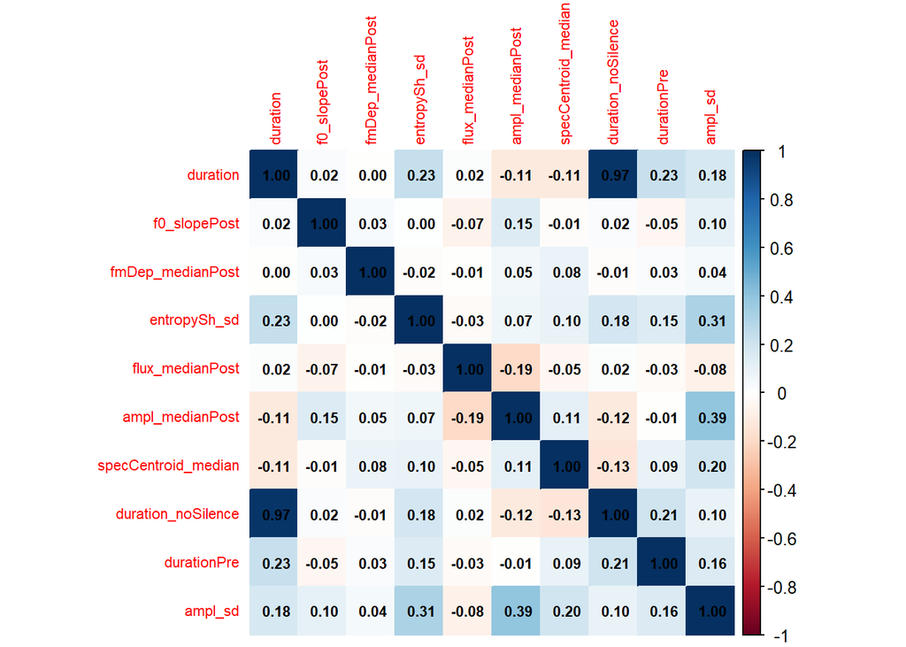

```r
# Calculate the correlation matrix
corrCat <- cor(data_prepost_cat[, c("duration", "f0_slopePost", "fmDep_medianPost",
                                    "entropySh_sd", "flux_medianPost",
                                    "ampl_medianPost", "specCentroid_median", "duration_noSilence",
                                    "durationPre", "ampl_sd")], use = "complete.obs")
corrplot(corrCat, method = "color", tl.cex = 0.7, number.cex = 0.7, addCoef.col = "black")
```

Let’s set contrasts for comparisons.

```r
# Drop unused levels of percProm
data_prepost_cat$percProm <- droplevels(data_prepost_cat$percProm)
# Set sum contrasts for percProm to compare all levels
#contrasts(data_prepost_cat$percProm) <- contr.sum(length(unique(data_prepost_cat$percProm)))
```

What is the mean for gender.

```r
summary(data_prepost_cat$gender_s)
```

```
##    Min. 1st Qu.  Median    Mean 3rd Qu.    Max.
## -0.5000 -0.5000  0.5000  0.1563  0.5000  0.5000
```

```r
# 0.1563
```

We go one by one the ten features from top to bottom.

### 4.1.1 Cumulative

```r
data_prepost_cat$percProm <- factor(data_prepost_cat$percProm,
                                   levels = c(1, 2, 3),
                                   ordered = TRUE)
```

#### 4.1.1.1 Formulas

```r
durCum <- bf(
  percProm ~
     duration +
     f0_slopePost +
     fmDep_medianPost +
     entropySh_sd +
     flux_medianPost +
     ampl_medianPost +
     specCentroid_median +
     durationPre +
     ampl_sd +
    (1 | participant)
)

durCum_ranSlopes <- bf(
  percProm ~
     duration +
     f0_slopePost +
     fmDep_medianPost +
     entropySh_sd +
     flux_medianPost +
     ampl_medianPost +
     specCentroid_median +
     durationPre +
     ampl_sd +
    (1 + duration +
     f0_slopePost +
     fmDep_medianPost +
     flux_medianPost +
     ampl_medianPost +
     specCentroid_median +
     durationPre +
     ampl_sd | participant)
)

durCum_allInt <- bf(
  percProm ~
    (duration +
     f0_slopePost +
     fmDep_medianPost +
     entropySh_sd +
     flux_medianPost +
     ampl_medianPost +
     specCentroid_median +
     durationPre +
     ampl_sd) *
    (duration +
     f0_slopePost +
     fmDep_medianPost +
     flux_medianPost +
     ampl_medianPost +
     specCentroid_median +
     durationPre +
     ampl_sd) +
    (1 + duration +
     f0_slopePost +
     fmDep_medianPost +
     flux_medianPost +
     ampl_medianPost +
     specCentroid_median +
     durationPre +
     ampl_sd | participant)
)
```

#### 4.1.1.2 Priors

| prior | class | coef | group | resp | dpar | nlpar | lb | ub | source |
| --- | --- | --- | --- | --- | --- | --- | --- | --- | --- |
|  | b |  |  |  |  |  |  |  | default |
|  | b | ampl_medianPost |  |  |  |  |  |  | default |
|  | b | ampl_sd |  |  |  |  |  |  | default |
|  | b | duration |  |  |  |  |  |  | default |
|  | b | durationPre |  |  |  |  |  |  | default |
|  | b | entropySh_sd |  |  |  |  |  |  | default |
|  | b | f0_slopePost |  |  |  |  |  |  | default |
|  | b | flux_medianPost |  |  |  |  |  |  | default |
|  | b | fmDep_medianPost |  |  |  |  |  |  | default |
|  | b | specCentroid_median |  |  |  |  |  |  | default |

[output cut: 6 more lines]

#### 4.1.1.3 Model

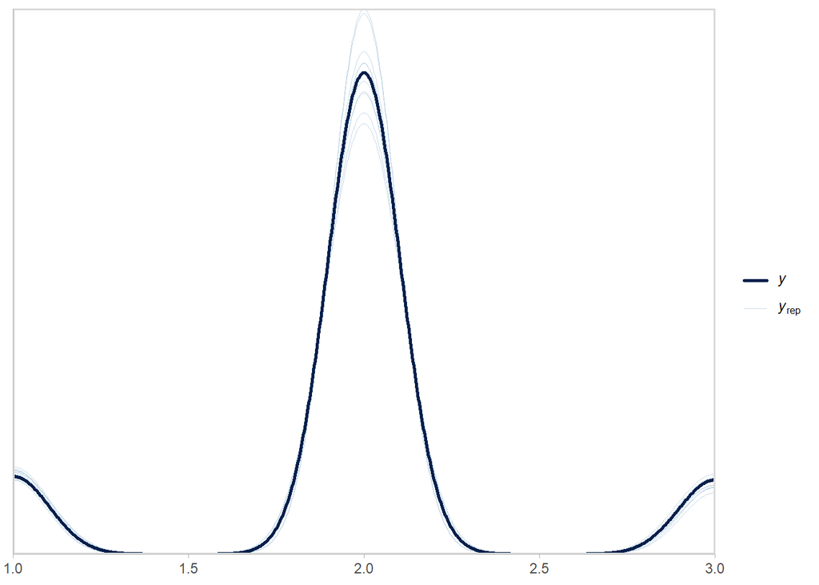

```r
pp_check(mdl_durCumCat)
```

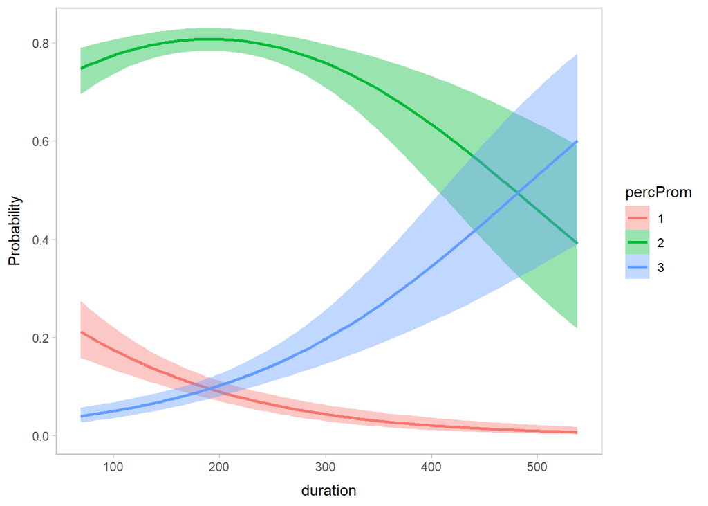

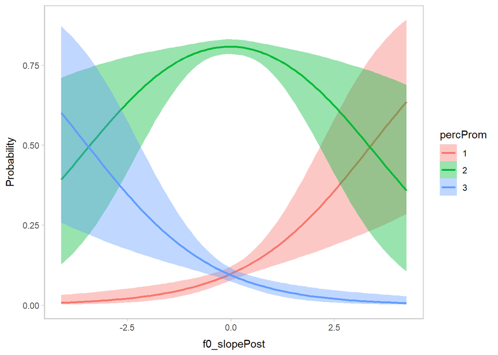

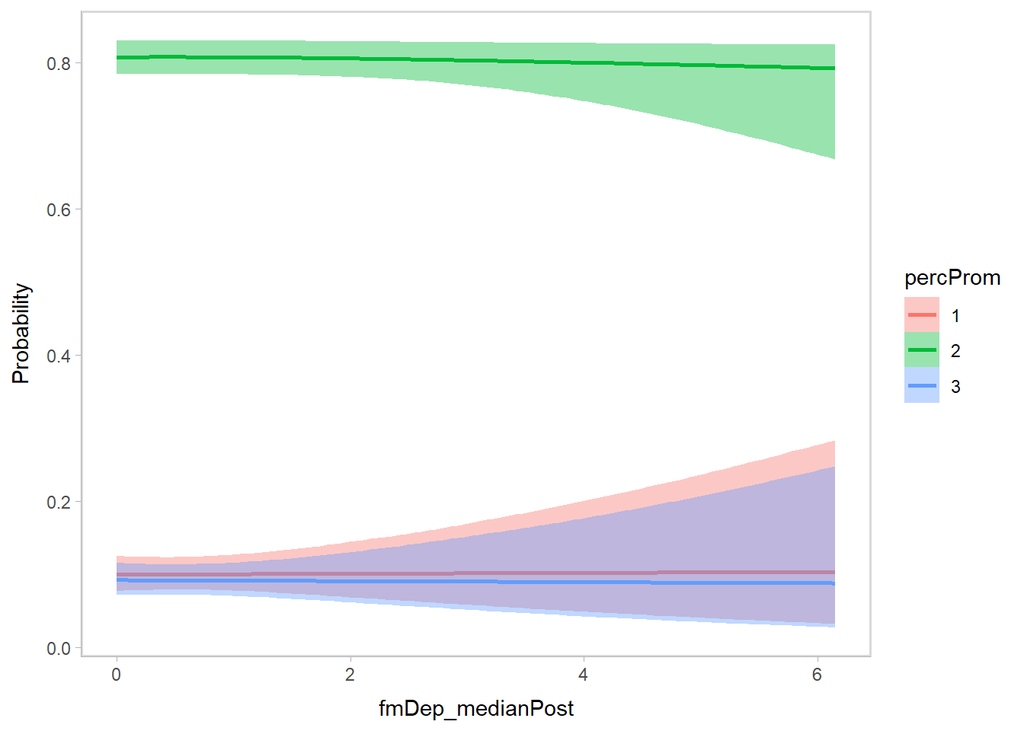

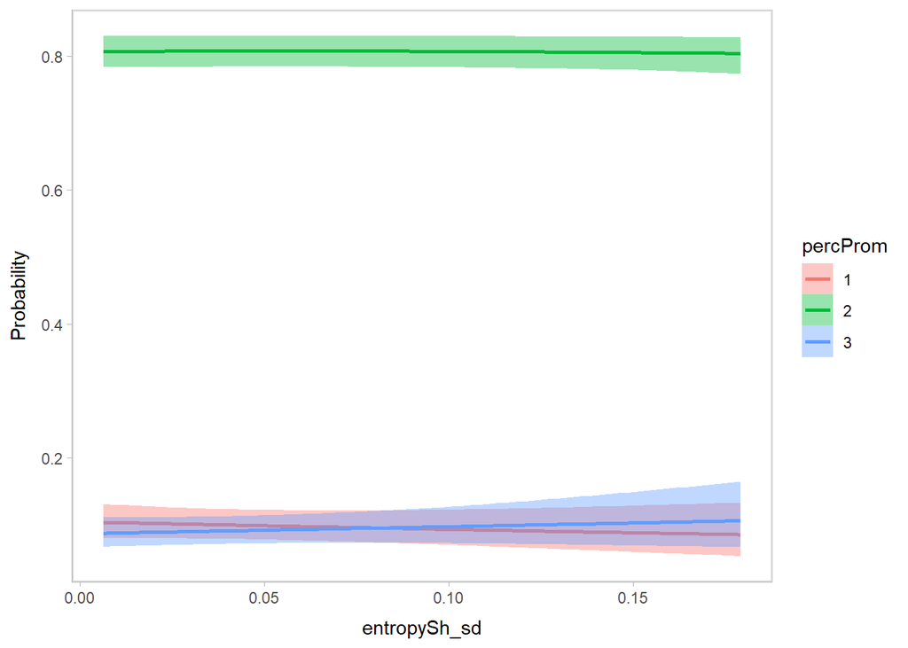

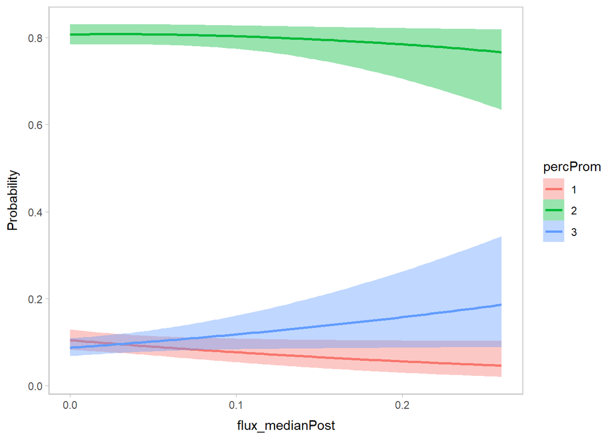

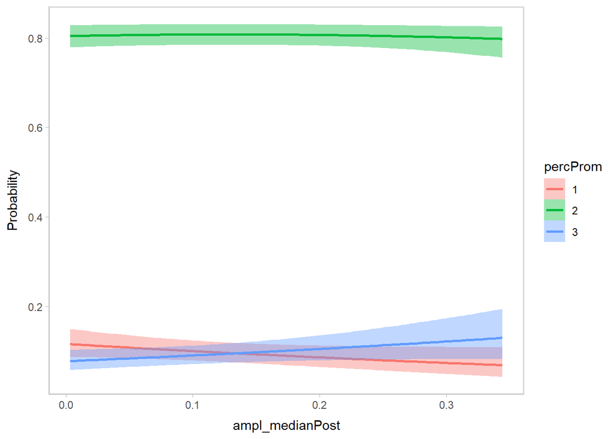

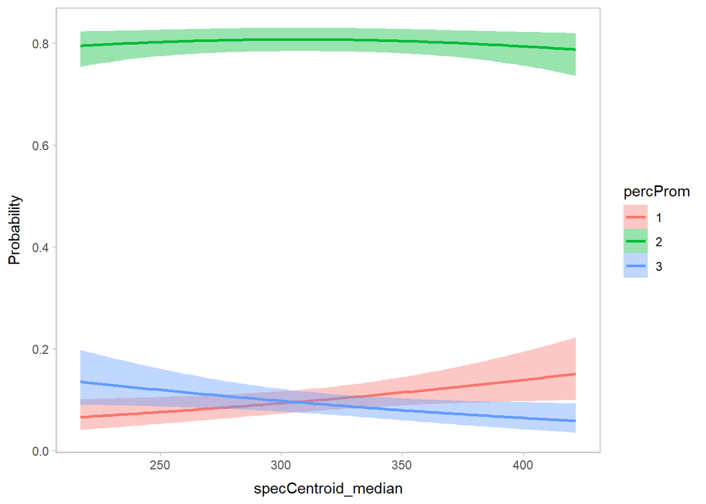

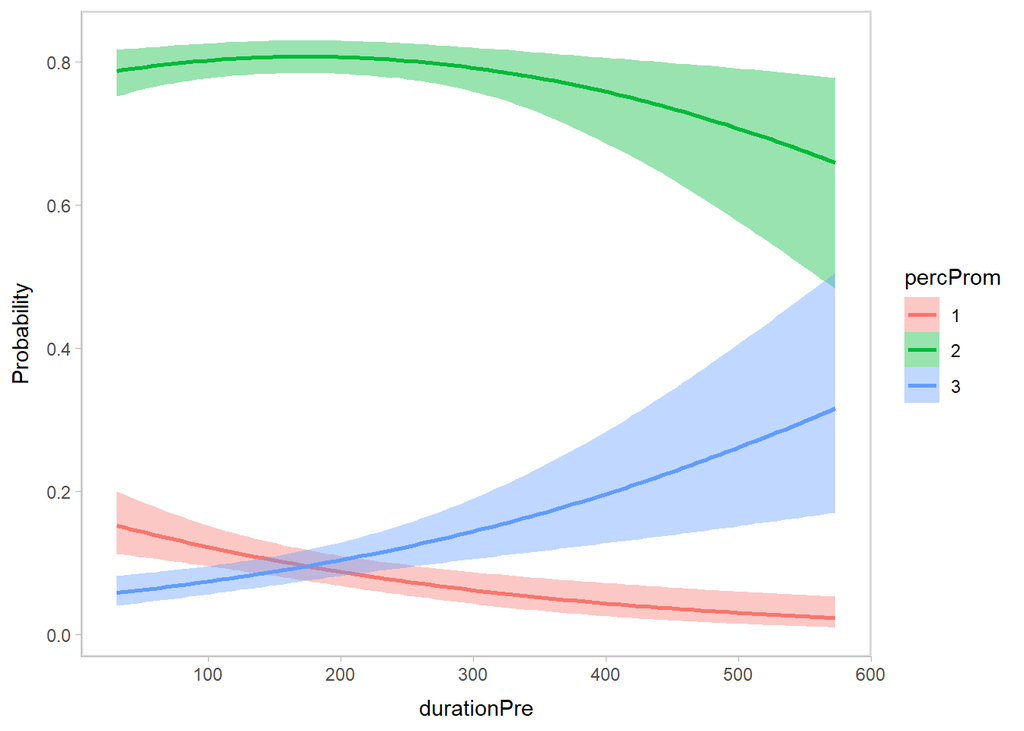

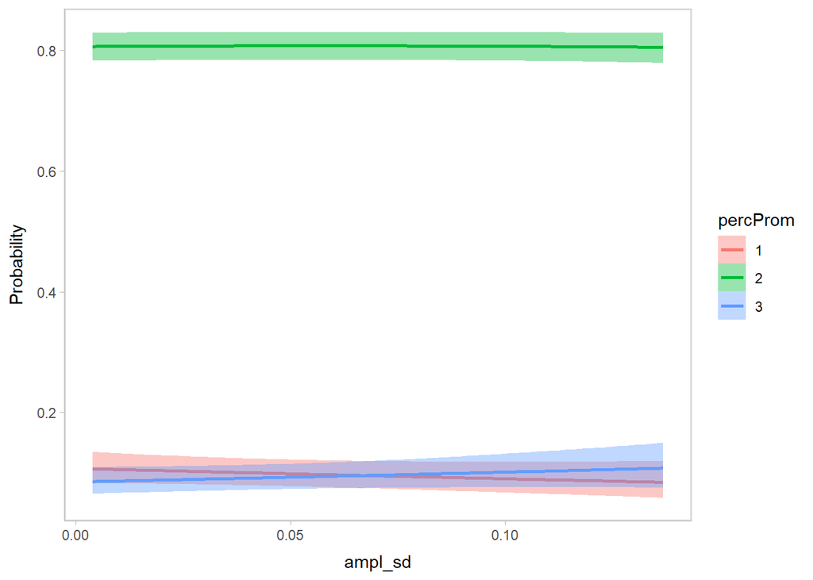

```r
conditional_effects(mdl_durCumCat, re_formula = NA, categorical = TRUE)
```

```r
hypothesis(mdl_durCumCat, c("duration = 0",
                            "f0_slopePost = 0",
                            "fmDep_medianPost = 0",
                            "entropySh_sd = 0",
                            "flux_medianPost = 0",
                            "ampl_medianPost = 0",
                            "specCentroid_median = 0",
                            "durationPre = 0",
                            "ampl_sd = 0"))
```

```
## Hypothesis Tests for class b:
##                 Hypothesis Estimate Est.Error CI.Lower CI.Upper Evid.Ratio
## 1           (duration) = 0     0.01      0.00     0.01     0.01         NA
## 2       (f0_slopePost) = 0    -0.66      0.18    -1.02    -0.30         NA
## 3   (fmDep_medianPost) = 0    -0.01      0.11    -0.22     0.20         NA
## 4       (entropySh_sd) = 0     1.23      1.65    -2.01     4.50         NA
## 5    (flux_medianPost) = 0     3.35      1.69     0.01     6.66         NA
## 6    (ampl_medianPost) = 0     1.65      0.91    -0.14     3.43         NA
## 7 (specCentroid_med... = 0     0.00      0.00    -0.01     0.00         NA
## 8        (durationPre) = 0     0.00      0.00     0.00     0.01         NA
## 9            (ampl_sd) = 0     1.92      1.60    -1.21     5.10         NA
##   Post.Prob Star
## 1        NA    *
## 2        NA    *
## 3        NA
## 4        NA
## 5        NA    *
## 6        NA
## 7        NA    *
## 8        NA    *
## 9        NA
## ---
## 'CI': 90%-CI for one-sided and 95%-CI for two-sided hypotheses.
## '*': For one-sided hypotheses, the posterior probability exceeds 95%;
## for two-sided hypotheses, the value tested against lies outside the 95%-CI.
## Posterior probabilities of point hypotheses assume equal prior probabilities.
```

### 4.1.2 Duration

#### 4.1.2.1 Priors

| prior | class | coef | group | resp | dpar | nlpar | lb | ub | source |
| --- | --- | --- | --- | --- | --- | --- | --- | --- | --- |
|  | b |  |  |  |  |  |  |  | default |
|  | b | gender_s |  |  |  |  |  |  | default |
|  | b | percProm1 |  |  |  |  |  |  | default |
|  | b | percProm2 |  |  |  |  |  |  | default |
|  | b | percProm3 |  |  |  |  |  |  | default |
| lkj(1) | cor |  |  |  |  |  |  |  | default |
|  | cor |  | participant |  |  |  |  |  | default |
| student_t(3, 0, 2.5) | sd |  |  |  |  |  | 0 |  | default |
|  | sd |  | participant |  |  |  |  |  | default |
|  | sd | percProm1 | participant |  |  |  |  |  | default |

[output cut: 3 more lines]

#### 4.1.2.2 Model

Calculate R².

```
##     Estimate  Est.Error      Q2.5     Q97.5
## R2 0.1724661 0.01381479 0.1460578 0.1997325
```

An R² of approximately **0.17** suggests a *modest fit*. This value indicates that the model explains about **17.2% of the variance** in the dependent variable `duration`. In other words, a small portion of the variability in `duration` is accounted for by the predictors in the model. The **95% credible interval**, ranging from **14.6% to 19.9%**, shows some uncertainty around this estimate but provides a stable indication of the model’s limited explanatory power.

#### 4.1.2.3 Fixed effects

Let’s check how it looks like.

```r
# Summarize the model
summary(mdl_durationCat)
```

```
##  Family: lognormal
##   Links: mu = identity; sigma = identity
## Formula: duration ~ 0 + percProm + gender_s + (0 + percProm | participant)
##    Data: data_prepost_cat (Number of observations: 2246)
##   Draws: 4 chains, each with iter = 8000; warmup = 4000; thin = 1;
##          total post-warmup draws = 16000
##
## Multilevel Hyperparameters:
## ~participant (Number of levels: 35)
##                          Estimate Est.Error l-95% CI u-95% CI Rhat Bulk_ESS
## sd(percProm1)                0.16      0.03     0.11     0.23 1.00     7165
## sd(percProm2)                0.14      0.02     0.11     0.18 1.00     6430
## sd(percProm3)                0.18      0.04     0.12     0.27 1.00     7623
## cor(percProm1,percProm2)     0.66      0.15     0.32     0.90 1.00     4310
## cor(percProm1,percProm3)     0.47      0.23    -0.02     0.85 1.00     4645
## cor(percProm2,percProm3)     0.68      0.15     0.32     0.92 1.00     6921
##                          Tail_ESS
## sd(percProm1)                9788
## sd(percProm2)                9675
## sd(percProm3)                9345
## cor(percProm1,percProm2)     6261
## cor(percProm1,percProm3)     7693
## cor(percProm2,percProm3)     9172
##
## Regression Coefficients:
##           Estimate Est.Error l-95% CI u-95% CI Rhat Bulk_ESS Tail_ESS
## percProm1     5.11      0.03     5.04     5.18 1.00     6387     8711
## percProm2     5.22      0.03     5.17     5.27 1.00     6428     9582
## percProm3     5.35      0.04     5.27     5.43 1.00     8611    11633
## gender_s      0.06      0.04     0.00     0.15 1.00     6584     8062
##
## Further Distributional Parameters:
##       Estimate Est.Error l-95% CI u-95% CI Rhat Bulk_ESS Tail_ESS
## sigma     0.33      0.01     0.32     0.34 1.00    23416    11411
##
## Draws were sampled using sampling(NUTS). For each parameter, Bulk_ESS
## and Tail_ESS are effective sample size measures, and Rhat is the potential
## scale reduction factor on split chains (at convergence, Rhat = 1).
```

```r
# Extract fixed effects
exp(fixef(mdl_durationCat))
```

```
##             Estimate Est.Error       Q2.5      Q97.5
## percProm1 165.351091  1.034530 154.740478 176.985674
## percProm2 184.973169  1.026270 175.846273 194.738125
## percProm3 211.451562  1.041156 194.961916 228.371297
## gender_s    1.064828  1.041079   1.003856   1.166572
```

It shows a stable increase from 1 to 3.

Diagnostic plots.

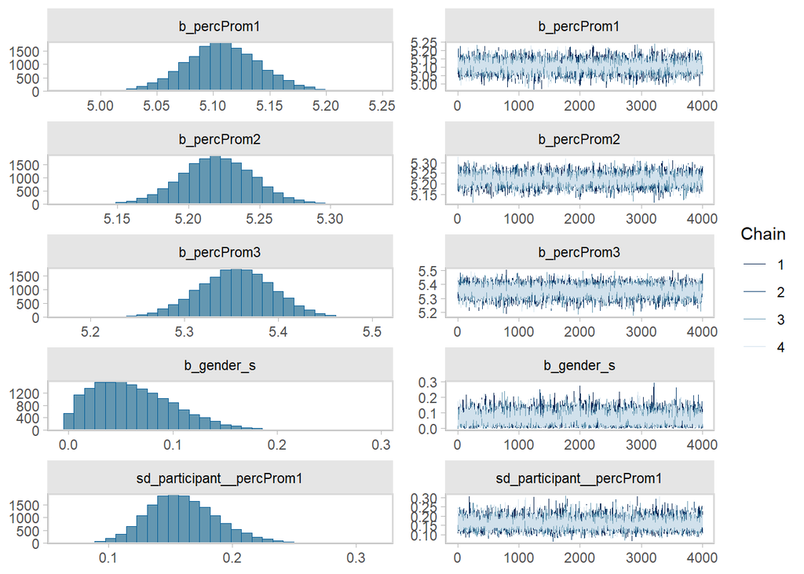

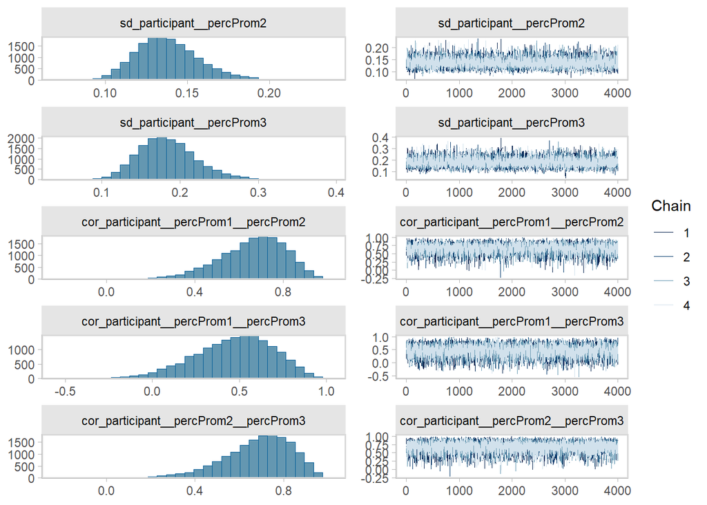

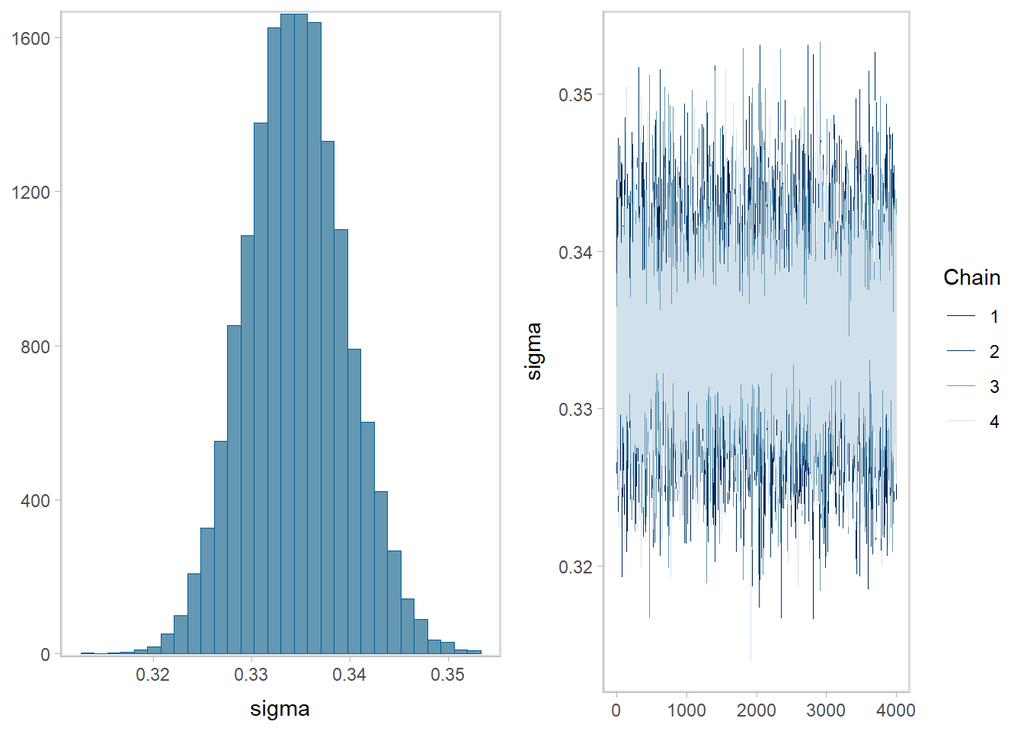

```r
plot(mdl_durationCat)
```

Posterior predictive check.

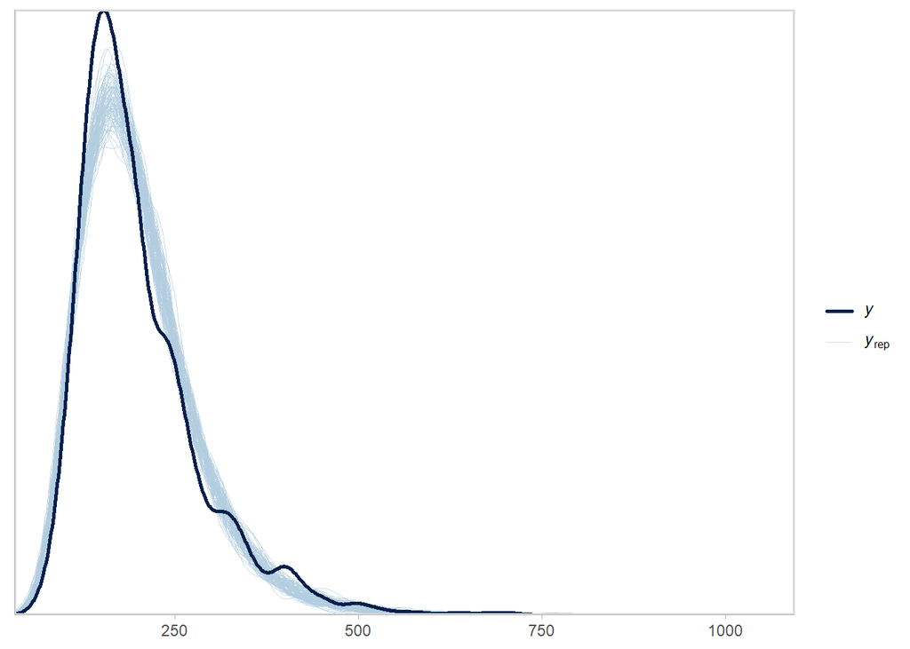

```r
pp_check(mdl_durationCat, ndraws = 100)
```

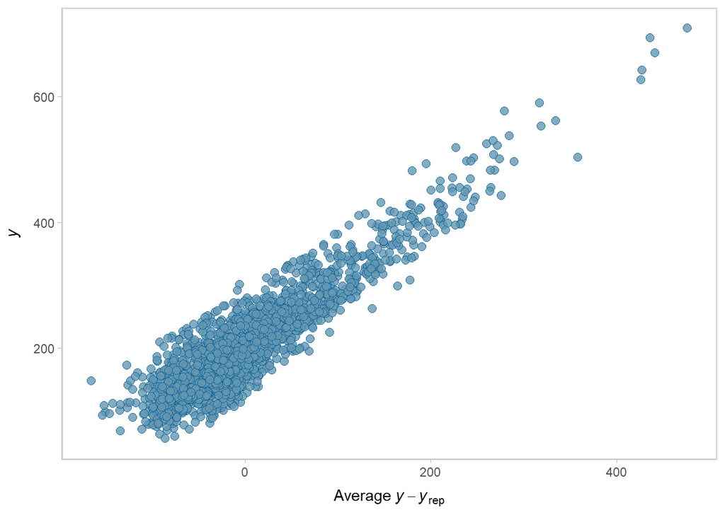

```r
pp_check(mdl_durationCat, type = "error_scatter_avg", ndraws = 100)
```

Extract samples.

| variable | mean | median | sd | mad | q5 | q95 | rhat | ess_bulk | ess_tail |
| --- | --- | --- | --- | --- | --- | --- | --- | --- | --- |
| b_percProm1 | 5.1080710 | 5.10739462 | 0.03394710 | 0.03286674 | 5.053376e+00 | 5.1643364 | 1.000373 | 6386.548 | 8710.631 |
| b_percProm2 | 5.2202108 | 5.22006863 | 0.02593096 | 0.02525466 | 5.177668e+00 | 5.2626365 | 1.000247 | 6428.332 | 9582.327 |
| b_percProm3 | 5.3539959 | 5.35466573 | 0.04033155 | 0.04008907 | 5.287116e+00 | 5.4190486 | 1.000194 | 8611.144 | 11633.008 |
| b_gender_s | 0.0628131 | 0.05723293 | 0.04025807 | 0.04166979 | 7.295497e-03 | 0.1374205 | 1.000120 | 6583.518 | 8062.103 |
| exp_b_percProm1 | 165.4464261 | 165.23928265 | 5.62165369 | 5.43401811 | 1.565501e+02 | 174.9213460 | 1.000372 | 6386.548 | 8710.631 |
| exp_b_percProm2 | 185.0353696 | 184.94687566 | 4.79959245 | 4.67461396 | 1.772689e+02 | 192.9896335 | 1.000247 | 6428.332 | 9582.327 |
| exp_b_percProm3 | 211.6232900 | 211.59323572 | 8.51584589 | 8.48255964 | 1.977723e+02 | 225.6643206 | 1.000194 | 8611.144 | 11633.008 |

Check conditional effect.

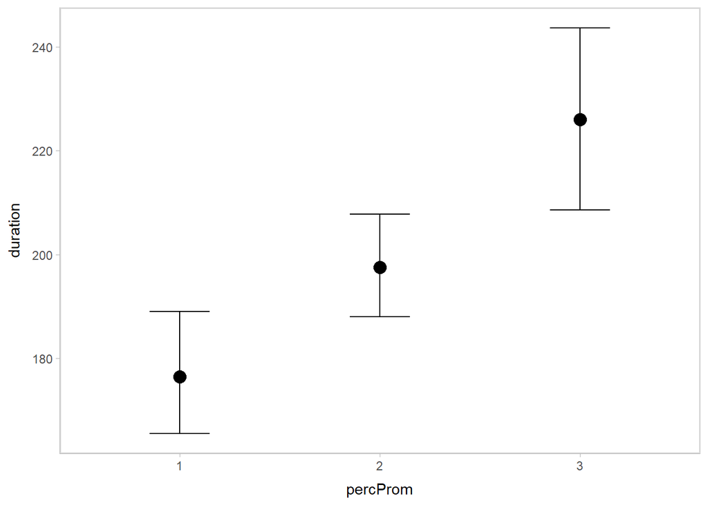

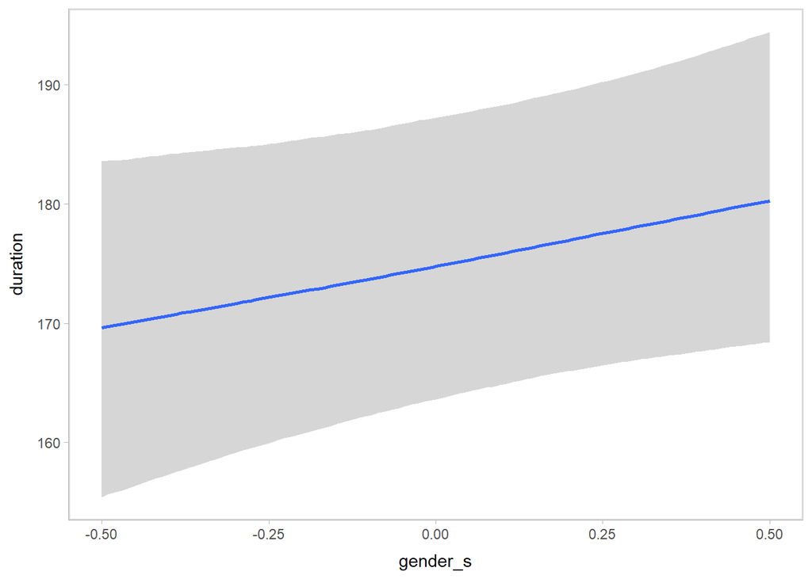

| percProm | duration | gender_s | participant | cond__ | effect1__ | estimate__ | se__ | lower__ | upper__ |
| --- | --- | --- | --- | --- | --- | --- | --- | --- | --- |
| 1 | 201.0214 | 0.1562778 | NA | 1 | 1 | 176.5016 | 5.709740 | 165.5582 | 189.0303 |
| 2 | 201.0214 | 0.1562778 | NA | 1 | 2 | 197.5284 | 4.793429 | 188.0034 | 207.7344 |
| 3 | 201.0214 | 0.1562778 | NA | 1 | 3 | 225.9863 | 8.854159 | 208.5451 | 243.6435 |

Compare conditional effects to raw values.

| percProm | avg_duration |
| --- | --- |
| 1 | 174.9165 |
| 2 | 200.0892 |
| 3 | 242.9253 |

```
##    Min. 1st Qu.  Median    Mean 3rd Qu.    Max.
##      56     144     180     201     238     709
```

##### 4.1.2.3.1 Effect comparison

```
##  percProm emmean lower.HPD upper.HPD
##  1           165       155       177
##  2           185       176       195
##  3           212       195       228
##
## Results are averaged over the levels of: gender_s
## Point estimate displayed: median
## HPD interval probability: 0.95
```

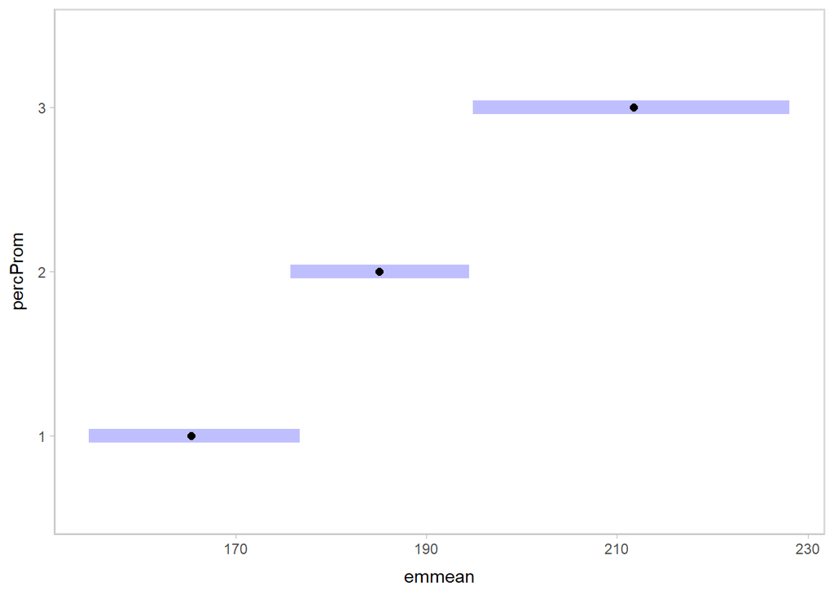

```
##  contrast              estimate lower.HPD upper.HPD
##  percProm1 - percProm2    -19.6     -29.7     -9.47
##  percProm1 - percProm3    -46.2     -62.9    -29.25
##  percProm2 - percProm3    -26.6     -40.5    -12.20
##
## Results are averaged over the levels of: gender_s
## Point estimate displayed: median
## HPD interval probability: 0.95
```

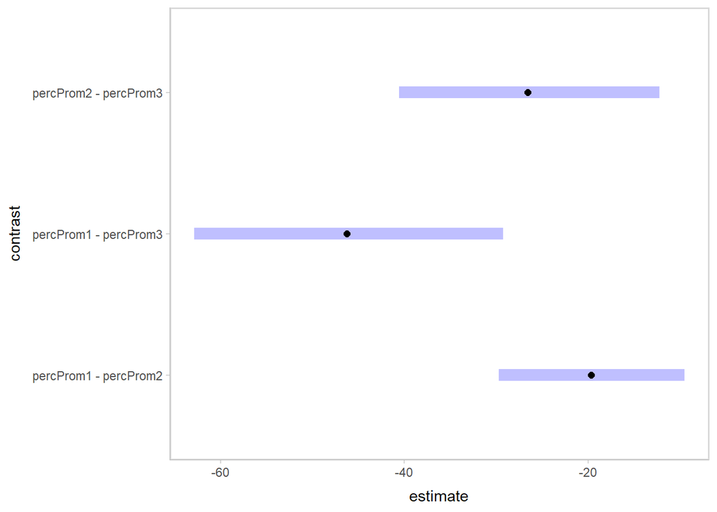

If the comparison includes 0, the contrast is not reliably different.

##### 4.1.2.3.2 Hypothesis testing

| Comparison | Estimate | Est.Error | CI.Lower | CI.Upper | Post.Prob | Star |
| --- | --- | --- | --- | --- | --- | --- |
| diff_1_2 | 19.589 | 5.138 | 9.356 | 29.595 | 99.94 | * |
| diff_1_3 | 46.177 | 8.602 | 29.283 | 62.902 | 100.00 | * |
| diff_2_3 | 26.588 | 7.245 | 12.464 | 40.822 | 99.98 | * |

**Overall Implications:**

- **Trend:** The results indicate a consistent increase in `duration` across `percProm` levels, moving from `percProm1` to `percProm3`.
- **Interpretation:** Each higher level of `percProm` is associated with a reliably longer `duration`. The strong posterior probabilities and credible intervals suggest that as perceived prominence (percProm) increases, so does `duration`, supporting a stable trend in the data.

##### 4.1.2.3.3 Plot fixef

Visualize the (non-)linearity of the effect with a violin plot of the posteriors for each prominence level and a GAMM overlaid on top.

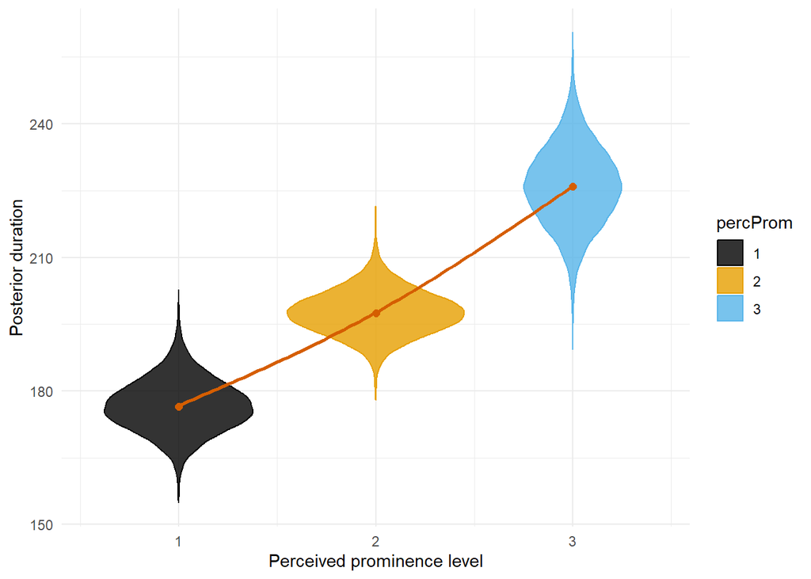

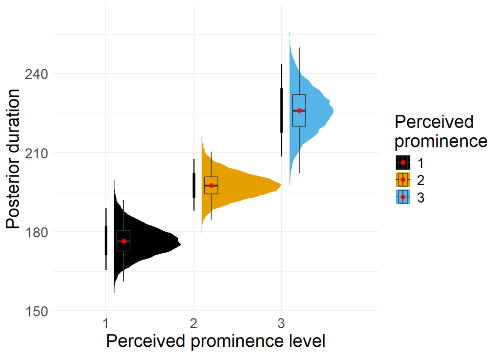

#### 4.1.2.4 Group-level effects

First, get a general overview.

| Random Effect | Estimate | Est.Error | Q2.5 | Q97.5 |
| --- | --- | --- | --- | --- |
| percProm1 | 0.1603835 | 0.02952548 | 0.1084774 | 0.2250592 |
| percProm2 | 0.1382488 | 0.01956249 | 0.1050902 | 0.1816348 |
| percProm3 | 0.1840569 | 0.03722956 | 0.1193543 | 0.2658824 |

- **percProm1:** The estimated standard deviation is 0.160 (95% CrI: 0.108 to 0.225), indicating moderate variability in participants’ response to `percProm1`.
- **percProm2:** The estimated standard deviation is 0.138 (95% CrI: 0.105 to 0.182), suggesting slightly less variability in participants’ response to `percProm2` compared to `percProm1`.
- **percProm3:** The estimated standard deviation is 0.184 (95% CrI: 0.119 to 0.266), showing increased variability in response to `percProm3` relative to the other prominence levels, indicating that participants exhibit a wider range of responses at this level.

**Overall Interpretation:** These results suggest that as perceived prominence increases from `percProm1` to `percProm3`, the variability in participants’ responses tends to fluctuate, with `percProm3` showing the highest variability. This pattern may imply that the highest level of perceived prominence elicits a more diverse range of responses in terms of `durationCat`.

Extract samples in interpretable units. Then, plot them so that we can see how each participant uses the levels of percProm.

| participant | percProm | gender_s | .row | .epred | .lower | .upper | .width | .point | .interval |
| --- | --- | --- | --- | --- | --- | --- | --- | --- | --- |
| 1 | 1 | 0.1563 | 1 | 219.2441 | 183.6886 | 265.8939 | 0.95 | median | qi |
| 1 | 2 | 0.1563 | 2 | 206.0595 | 185.4907 | 229.0205 | 0.95 | median | qi |
| 1 | 3 | 0.1563 | 3 | 264.1871 | 224.3315 | 311.5357 | 0.95 | median | qi |
| 2 | 1 | 0.1563 | 4 | 162.4148 | 135.3071 | 191.1309 | 0.95 | median | qi |
| 2 | 2 | 0.1563 | 5 | 207.6486 | 189.4537 | 228.2510 | 0.95 | median | qi |
| 2 | 3 | 0.1563 | 6 | 231.9731 | 197.9049 | 271.1365 | 0.95 | median | qi |
| 3 | 1 | 0.1563 | 7 | 178.7933 | 152.6708 | 207.5980 | 0.95 | median | qi |
| 3 | 2 | 0.1563 | 8 | 215.1192 | 196.4336 | 235.7522 | 0.95 | median | qi |
| 3 | 3 | 0.1563 | 9 | 256.4715 | 224.6435 | 293.8019 | 0.95 | median | qi |
| 4 | 1 | 0.1563 | 10 | 186.2459 | 160.4316 | 215.4511 | 0.95 | median | qi |

[output cut: 95 more lines]

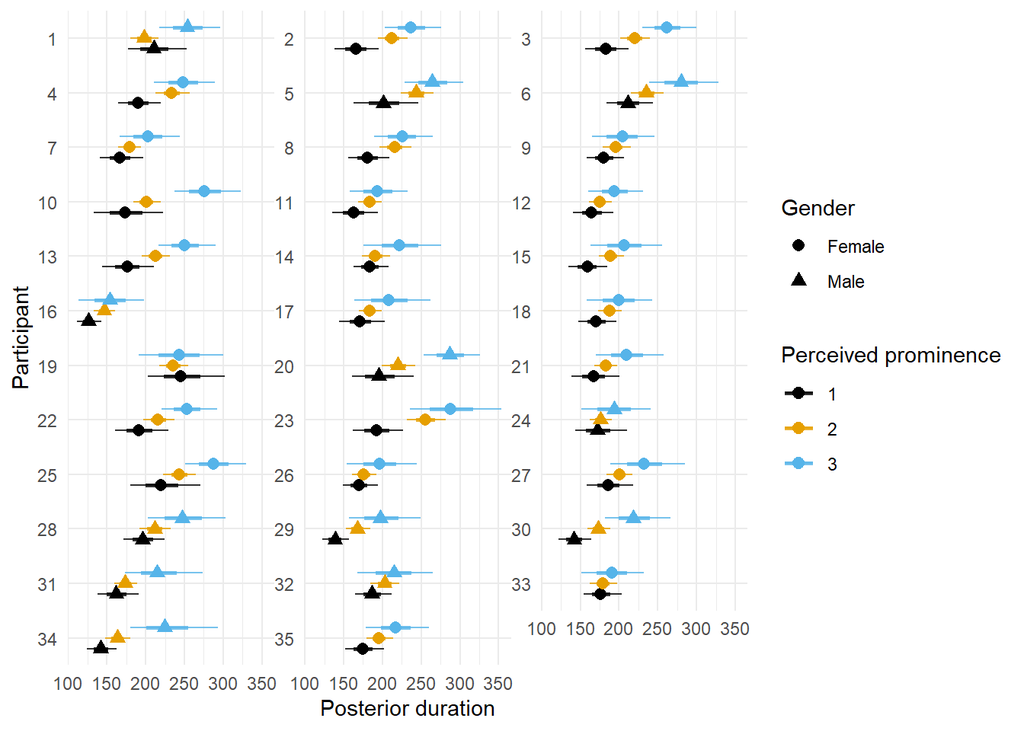

First, we extract individual draws. Here, if the CrI encompasses 0, the participant does not differ from the overall behavior on this percProm. Then, we plot random effects for each participant and percProm level on the model scale, representing deviations from the fixed effects.

| participant | percProm | r_participant | .lower | .upper | .width | .point | .interval |
| --- | --- | --- | --- | --- | --- | --- | --- |
| 1 | percProm1 | 0.2160594403 | 0.0368077181 | 4.123313e-01 | 0.95 | median | qi |
| 1 | percProm2 | 0.0425047525 | -0.0721375359 | 1.553869e-01 | 0.95 | median | qi |
| 1 | percProm3 | 0.1554825198 | -0.0160112705 | 3.409476e-01 | 0.95 | median | qi |
| 2 | percProm1 | -0.0839667467 | -0.2742990747 | 8.626593e-02 | 0.95 | median | qi |
| 2 | percProm2 | 0.0500083780 | -0.0514161153 | 1.525078e-01 | 0.95 | median | qi |
| 2 | percProm3 | 0.0256511095 | -0.1406671666 | 1.944197e-01 | 0.95 | median | qi |
| 3 | percProm1 | 0.0122587635 | -0.1498075301 | 1.672747e-01 | 0.95 | median | qi |
| 3 | percProm2 | 0.0857845160 | -0.0140209020 | 1.862704e-01 | 0.95 | median | qi |
| 3 | percProm3 | 0.1258467088 | -0.0189252678 | 2.808474e-01 | 0.95 | median | qi |
| 4 | percProm1 | 0.0532798859 | -0.1021507181 | 2.062630e-01 | 0.95 | median | qi |

[output cut: 95 more lines]

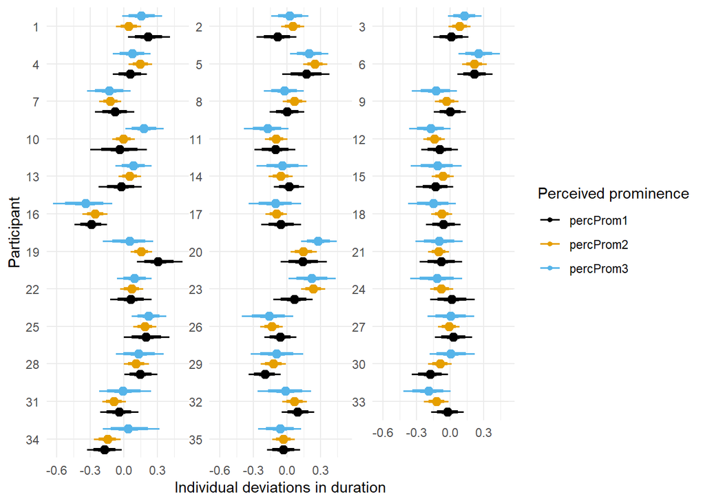

### 4.1.3 F0 slope (post-tonic)

#### 4.1.3.1 Priors

| prior | class | coef | group | resp | dpar | nlpar | lb | ub | source |
| --- | --- | --- | --- | --- | --- | --- | --- | --- | --- |
|  | b |  |  |  |  |  |  |  | default |
|  | b | gender_s |  |  |  |  |  |  | default |
|  | b | percProm1 |  |  |  |  |  |  | default |
|  | b | percProm2 |  |  |  |  |  |  | default |
|  | b | percProm3 |  |  |  |  |  |  | default |
| lkj(1) | cor |  |  |  |  |  |  |  | default |
|  | cor |  | participant |  |  |  |  |  | default |
| gamma(2, 0.1) | nu |  |  |  |  |  | 1 |  | default |
| student_t(3, 0, 2.5) | sd |  |  |  |  |  | 0 |  | default |
|  | sd |  | participant |  |  |  |  |  | default |

[output cut: 4 more lines]

#### 4.1.3.2 Model

Calculate R².

```
##      Estimate   Est.Error       Q2.5      Q97.5
## R2 0.06645816 0.007244046 0.05251865 0.08075153
```

An R² of approximately 0.07 suggests a **weak fit**, indicating that the model explains only about **6.6% of the variance** in the dependent variable `f0_slopePostCat`. In other words, a small portion of the variability in `f0_slopePostCat` is accounted for by the predictors in the model. The 95% credible interval, ranging from **5.3% to 8.1%**, reflects some uncertainty around this estimate, but it generally confirms the model’s limited explanatory power.

#### 4.1.3.3 Fixed effects

Let’s check how it looks like.

```r
# Summarize the model
summary(mdl_f0_slopePostCat)
```

```
##  Family: student
##   Links: mu = identity; sigma = identity; nu = identity
## Formula: f0_slopePost ~ 0 + percProm + gender_s + (0 + percProm | participant)
##    Data: data_prepost_cat (Number of observations: 1780)
##   Draws: 4 chains, each with iter = 8000; warmup = 4000; thin = 1;
##          total post-warmup draws = 16000
##
## Multilevel Hyperparameters:
## ~participant (Number of levels: 35)
##                          Estimate Est.Error l-95% CI u-95% CI Rhat Bulk_ESS
## sd(percProm1)                0.03      0.02     0.00     0.06 1.00     3199
## sd(percProm2)                0.08      0.01     0.06     0.11 1.00     6465
## sd(percProm3)                0.09      0.02     0.05     0.14 1.00     6050
## cor(percProm1,percProm2)     0.15      0.41    -0.73     0.85 1.00      691
## cor(percProm1,percProm3)     0.16      0.43    -0.72     0.88 1.00     1503
## cor(percProm2,percProm3)     0.36      0.24    -0.18     0.76 1.00    10503
##                          Tail_ESS
## sd(percProm1)                6030
## sd(percProm2)                9786
## sd(percProm3)                6791
## cor(percProm1,percProm2)     1116
## cor(percProm1,percProm3)     2586
## cor(percProm2,percProm3)    11607
##
## Regression Coefficients:
##           Estimate Est.Error l-95% CI u-95% CI Rhat Bulk_ESS Tail_ESS
## percProm1     0.00      0.01    -0.02     0.03 1.00     7434    10709
## percProm2     0.06      0.02     0.03     0.09 1.00     7191     9945
## percProm3    -0.08      0.02    -0.12    -0.03 1.00    10715    11007
## gender_s     -0.01      0.02    -0.05     0.03 1.00     9400     9275
##
## Further Distributional Parameters:
##       Estimate Est.Error l-95% CI u-95% CI Rhat Bulk_ESS Tail_ESS
## sigma     0.13      0.01     0.12     0.14 1.00    12273    12072
## nu        2.00      0.14     1.75     2.29 1.00    14263    11993
##
## Draws were sampled using sampling(NUTS). For each parameter, Bulk_ESS
## and Tail_ESS are effective sample size measures, and Rhat is the potential
## scale reduction factor on split chains (at convergence, Rhat = 1).
```

```r
# Extract fixed effects
fixef(mdl_f0_slopePostCat)
```

```
##               Estimate  Est.Error        Q2.5       Q97.5
## percProm1  0.004748638 0.01197570 -0.01867902  0.02921571
## percProm2  0.062793941 0.01593530  0.03176724  0.09456290
## percProm3 -0.078127142 0.02124579 -0.11879674 -0.03435458
## gender_s  -0.010273064 0.01895841 -0.04863810  0.02640334
```

It shows a stable increase from 1 to 2, and then a drop from 2 to 3.

Diagnostic plots.

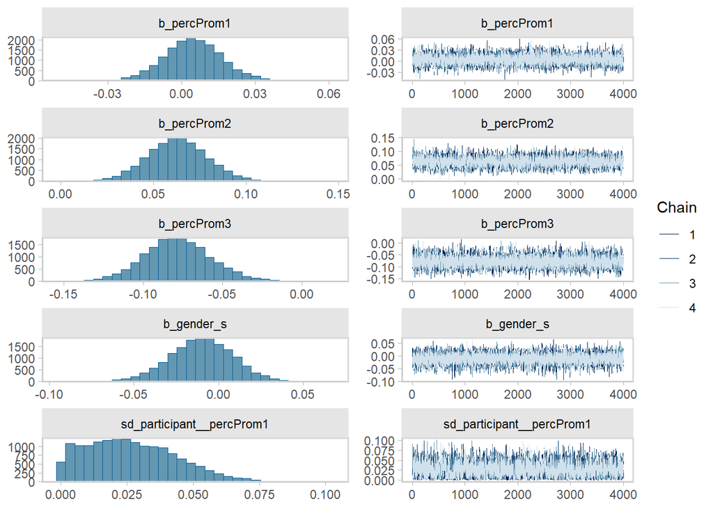

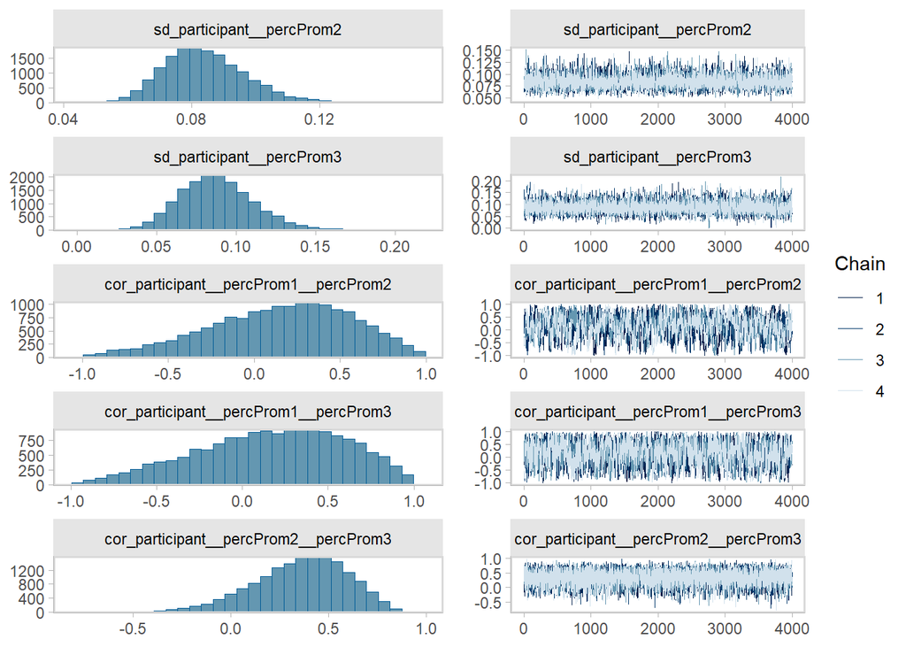

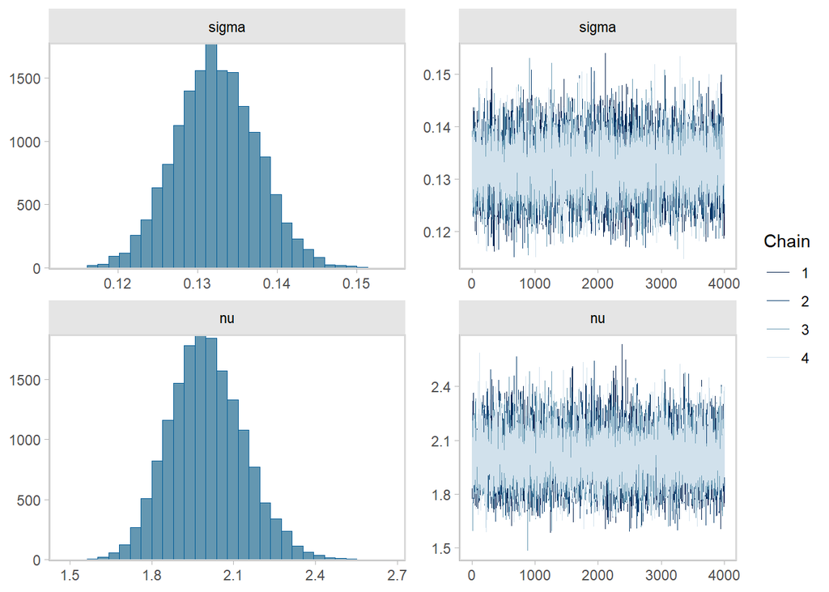

```r
plot(mdl_f0_slopePostCat)
```

Posterior predictive check.

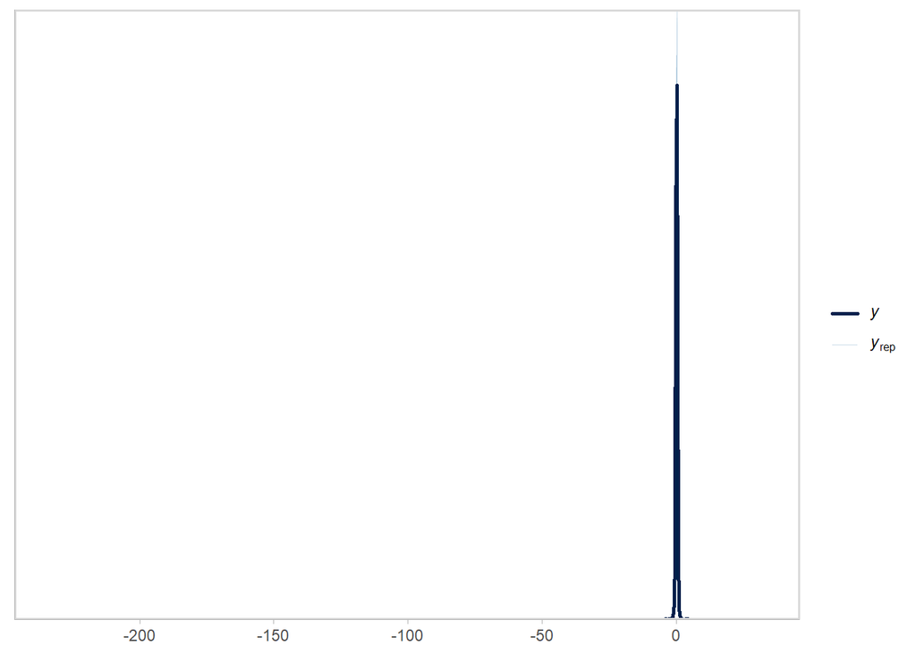

```r
pp_check(mdl_f0_slopePostCat, ndraws = 100)
```

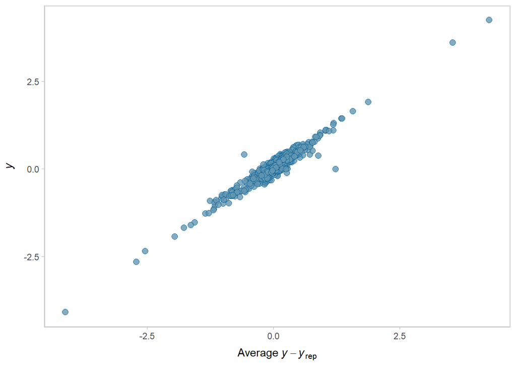

```r
pp_check(mdl_f0_slopePostCat, type = "error_scatter_avg", ndraws = 100)
```

Extract samples.

```r
# Extract posterior samples of fixed effects
samples_mdl_f0_slopePostCat <- as_draws_array(mdl_f0_slopePostCat,
                                          variable = "^b_",
                                          regex = TRUE)

# Summarize posterior draws
summarize_draws(samples_mdl_f0_slopePostCat)
```

| variable | mean | median | sd | mad | q5 | q95 | rhat | ess_bulk | ess_tail |
| --- | --- | --- | --- | --- | --- | --- | --- | --- | --- |
| b_percProm1 | 0.004748638 | 0.004527844 | 0.01197570 | 0.01156819 | -0.01469070 | 0.02477540 | 1.000469 | 7433.513 | 10708.872 |
| b_percProm2 | 0.062793941 | 0.062724643 | 0.01593530 | 0.01572559 | 0.03649829 | 0.08918792 | 1.000570 | 7191.216 | 9944.827 |
| b_percProm3 | -0.078127142 | -0.078696348 | 0.02124579 | 0.02048316 | -0.11215829 | -0.04207402 | 1.000327 | 10715.351 | 11007.495 |
| b_gender_s | -0.010273064 | -0.009925511 | 0.01895841 | 0.01858639 | -0.04176451 | 0.02002509 | 1.000607 | 9399.706 | 9274.510 |

Check conditional effect.

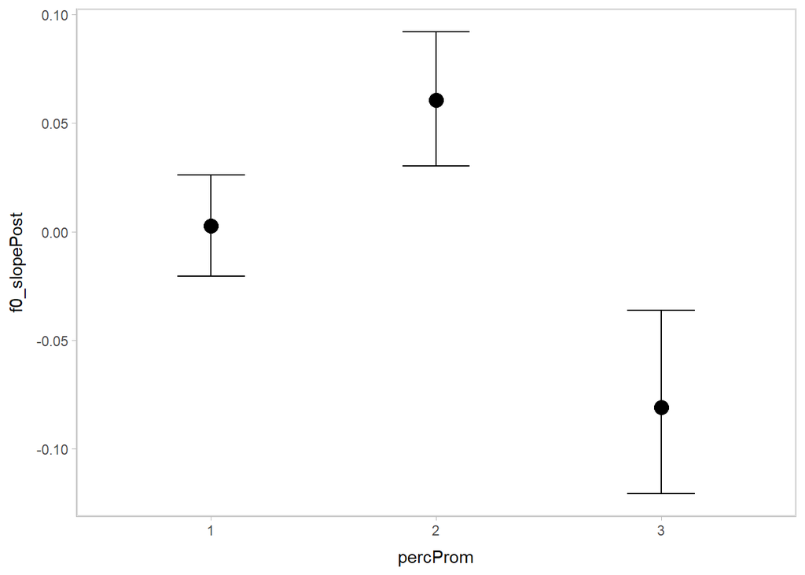

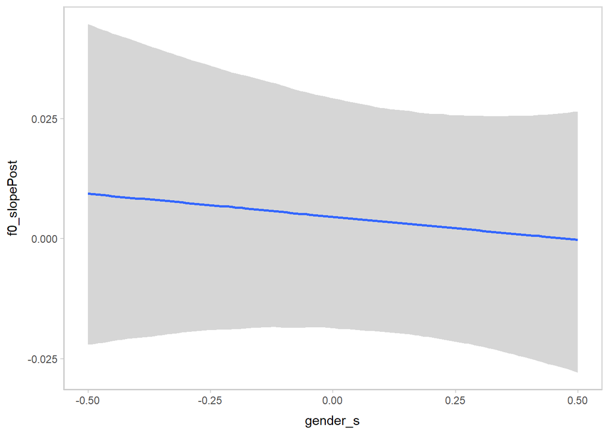

```r
# Plot conditional effects (fixed effects only)
conditional_effects(mdl_f0_slopePostCat, re_formula = NA)
```

```r
# Extract conditional effects data
conditional_effects(mdl_f0_slopePostCat, plot = FALSE, re_formula = NA)$percProm
```

| percProm | f0_slopePost | gender_s | participant | cond__ | effect1__ | estimate__ | se__ | lower__ | upper__ |
| --- | --- | --- | --- | --- | --- | --- | --- | --- | --- |
| 1 | 0.03240117 | 0.1910112 | NA | 1 | 1 | 0.002723245 | 0.01118625 | -0.02045750 | 0.02615954 |
| 2 | 0.03240117 | 0.1910112 | NA | 1 | 2 | 0.060617656 | 0.01549188 | 0.03028062 | 0.09204656 |
| 3 | 0.03240117 | 0.1910112 | NA | 1 | 3 | -0.080793257 | 0.02026860 | -0.12048344 | -0.03634140 |

Compare conditional effects to raw values.

```r
# Calculate raw means by percProm level
data_prepost_cat %>%
  group_by(percProm) %>%
  summarize(avg_f0_slopePost = mean(f0_slopePost, na.rm = TRUE))
```

| percProm | avg_f0_slopePost |
| --- | --- |
| 1 | 0.02205775 |
| 2 | 0.05646742 |
| 3 | -0.10105694 |

```r
# Summary of f0_slopePost
summary(data_prepost_cat$f0_slopePost)
```

```
##    Min. 1st Qu.  Median    Mean 3rd Qu.    Max.    NA's
## -4.0920 -0.0858  0.0052  0.0324  0.1774  4.2460     466
```